# 통계밥법론2 Chap9 실습코드

202140191 엄태훈

2021-11-13(SAT)

# Chap9 Loglinear and Logit Models for Contingency Tables

**Chapter9**에서는 분할표 데이터를 이용하여 **Loglinear model**과 **Logit model**을 적합시키는 방법에 대해서 알아본다.  
이러한 모델들은 **mosaic plot**을 통해 시각화 하는것이 가장 적합하다.

## 9.1 Introduction

**로지스틱 회귀 모델**의 경우 하나의 반응 변수의 예측에 대해 초점을 맞추지만, **로그선형 모델**의 경우 **모든 변수를 대칭**으로 처리하여, 각 변수사이의 **중요한 연관성**을 모형화한다. 여기서, 로그선형 모형의 목적은 변수간의 의존성 및 독립성의 패턴을 파악하는 것이다.

앞선 챕터에서, 로그 선형모형의 기본적인 측면을 살펴봤다면, 이번 장에서는 모형을 적합하고 해석하는데 초점을 둔다. 또한, 분할표의 차원이 큰 경우 **로그 오즈 그림** 혹은 **모자이크 플롯**을 통해 연관성의 특징을 보다 쉽게 이해할 수 있다.

## 9.2 Loglinear models for frequencies

**로그선형 모델**은 양적 데이터에 대한 결합, 주변확률 사이의 곱셈 관계를 로그로 변환하여 사용한다. 카운트를 로그로 변환해주는 이유는 카운트가 0인 경우 결과가 0으로 나오기 때문에 로그를 적용하여 이러한 위험을 방지하는 것이다.

```r
options("contrasts")
```

```
## $contrasts
##         unordered           ordered
## "contr.treatment"      "contr.poly"
```

인자에 대한 매개변수화는 주어진 인자가 명목형인지 순서형인지에 따라 달라지는 것을 확인할 수 있다.  
`unordered`의 경우, 처리에 대한 모수화를 사용하지만, `ordered`의 경우 다항식에 기반한 모수화를 사용하는 것을 확인할 수 있다.

## 9.3 Fitting and testing loglinear models

로그선형 모델의 경우, 상호 독립을 가정하는 **[A][B]][C]**모델부터, 완벽한 포화모델인 [ABC]까지 다양한 독립성 가정을하여 모델을 적합시킬 수 있다.

### 9.3.1 Model fitting functions

```r
set.seed(42)
n <- 100
A <- factor(sample(c("a1", "a2"), n, replace = TRUE))
B <- factor(sample(c("b1", "b2"), n, replace = TRUE))
C <- factor(sample(c("M", "F"), n, replace = TRUE))
Freq <- round(rnorm(n, mean = 30, sd = 5))
mydata <- data.frame(A, B, C, Freq)
mytable <- xtabs(~ A + B + C, data = mydata)
```

```r
loglin(mytable, margin = list(c(1,2), c(1,3), c(2,3)))
```

```
## 3 iterations: deviation 0.01472342
```

```
## $lrt
## [1] 6.196281
##
## $pearson
## [1] 5.964879
##
## $df
## [1] 1
##
## $margin
## $margin[[1]]
## [1] "A" "B"
##
## $margin[[2]]
## [1] "A" "C"
##
## $margin[[3]]
## [1] "B" "C"
```

```r
library(MASS)
loglm(~ (A+B+C)^2, data = mytable)
```

```
## Call:
## loglm(formula = ~(A + B + C)^2, data = mytable)
##
## Statistics:
##                       X^2 df  P(> X^2)
## Likelihood Ratio 6.196281  1 0.0128019
## Pearson          5.964879  1 0.0145936
```

```r
loglm(Freq ~ (A+B+C)^2, data = mydata)
```

```
## Call:
## loglm(formula = Freq ~ (A + B + C)^2, data = mydata)
##
## Statistics:
##                       X^2 df  P(> X^2)
## Likelihood Ratio 68.22202 93 0.9749430
## Pearson          67.90936 93 0.9765542
```

```r
glm(Freq ~ (A+B+C)^2, data = mydata, family = poisson)
```

```
##
## Call:  glm(formula = Freq ~ (A + B + C)^2, family = poisson, data = mydata)
##
## Coefficients:
## (Intercept)          Aa2          Bb2           CM      Aa2:Bb2       Aa2:CM
##     3.30879      0.05623      0.10501      0.08111     -0.08680     -0.01198
##      Bb2:CM
##    -0.05337
##
## Degrees of Freedom: 99 Total (i.e. Null);  93 Residual
## Null Deviance:       70.81
## Residual Deviance: 68.22     AIC: 605.3
```

```r
summary(glm(Freq ~ (A+B+C)^2, data = mydata, family = poisson))
```

```
##
## Call:
## glm(formula = Freq ~ (A + B + C)^2, family = poisson, data = mydata)
##
## Deviance Residuals:
##      Min        1Q    Median        3Q       Max
## -1.94816  -0.57262  -0.02151   0.56034   1.83943
##
## Coefficients:
##             Estimate Std. Error z value Pr(>|z|)
## (Intercept)  3.30879    0.08429  39.257   <2e-16 ***
## Aa2          0.05623    0.08546   0.658    0.511
## Bb2          0.10501    0.08547   1.229    0.219
## CM           0.08111    0.08546   0.949    0.343
## Aa2:Bb2     -0.08680    0.08056  -1.077    0.281
## Aa2:CM      -0.01198    0.08048  -0.149    0.882
## Bb2:CM      -0.05337    0.08069  -0.661    0.508
## ---
## Signif. codes:  0 '***' 0.001 '**' 0.01 '*' 0.05 '.' 0.1 ' ' 1
##
## (Dispersion parameter for poisson family taken to be 1)
##
##     Null deviance: 70.811  on 99  degrees of freedom
## Residual deviance: 68.222  on 93  degrees of freedom
## AIC: 605.3
##
## Number of Fisher Scoring iterations: 4
```

### 9.3.2 Goodness-of-fit tests

모델을 적합시킨 후에, 주어진 모델이 주어진 데이터를 얼마나 설명할 수 있고 얼마나 적합한지에 대해 **Goodness-of-fit test**를 통해 확인할 수 있다.  
가장 일반적으로 사용되는 방법은 **Pearson 카이제곱검정**, **우도비 검정** 등이 있다.

### 9.3.3 Residuals for loglinear models

모델의 적합도 검정을 진행한 후, 각 데이터의 패턴을 살펴보고 싶을 수 있다.  
이러한 경우, 쉽게 예시로 생각할 수 있는것 중 하나는 **피어슨 잔차**를 통해 데이터의 패턴을 살펴보는 것이다.  
앞선 chapter에서 살펴본대로, 잔차가 양의 값을 가질경우, 예상된 케이스보다 많은 것을 확인할 수 있고 음의 값을 가질경우, 예상된 케이스보다 적은 것을 확인할 수 있다.  
또 하나의 방법은 Haberman이 제시한 Pearson 잔차를 표준 오차로 나눈 이른바 **신뢰 잔차**라고 하는 값을 살펴보는 것이다.

`R`에서는 `glm`을 통해 모델을 적합시키면 `hatvalue`를 얻을 수 있고 이 값을 통해 **수정 잔차 값**을 구할 수 있다.  
일반적으로 **수정 잔차는** $sqrt(1-h)$으로 정의한다.

```r
berkeley <- as.data.frame(UCBAdmissions)
berk.glm1 <- glm(Freq ~ Dept * (Gender + Admit), data = berkeley,
                family = "poisson")
fit <- fitted(berk.glm1)
hat <- hatvalues(berk.glm1)
stderr <- sqrt(1 - hat)
```

`glm`에서 얻은 `hatvalue`와 `fit`값을 이용하여 **수정잔차**를 구한 후, **stderr**객체에 저장하였다.

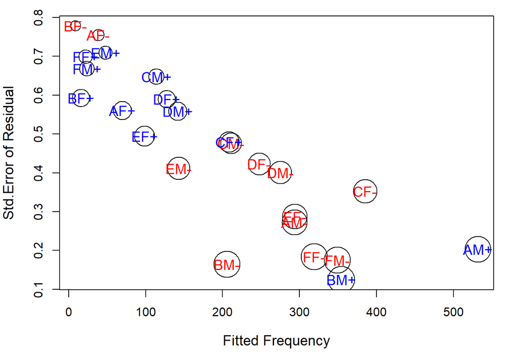

```r
op <- par(mar = c(5,4,1,1)+.1)
plot(fit, stderr, cex = 5 *hat,
     ylab = "Std.Error of Residual", xlab = "Fitted Frequency",
     cex.lab = 1.2)
labs <- with(berkeley,
             paste(Dept, substr(Gender, 1, 1), ifelse(Admit == "Admitted", "+", "-"), sep = ""))
col <- ifelse(berkeley$Admit == "Admitted", "blue", "red")
text(fit,stderr,labs,col=col,cex = 1.2)
```

```r
par(op)
```

### 9.3.4 Using loglm()

*Example 9.1: Berkeley admissions*

```r
data("UCBAdmissions")
berk.loglm0 <- loglm(~ Dept + Gender + Admit, data = UCBAdmissions, param = TRUE, fitted = TRUE)
berk.loglm0
```

```
## Call:
## loglm(formula = ~Dept + Gender + Admit, data = UCBAdmissions,
##     param = TRUE, fitted = TRUE)
##
## Statistics:
##                       X^2 df P(> X^2)
## Likelihood Ratio 2097.671 16        0
## Pearson          2000.328 16        0
```

`UCBAdmissions`에 대해 `loglm`함수를 사용하여 로그선형 모델을 적합시켰다.  
출력된 유의확률이 유의수준 0.05보다 작으므로 귀무가설을 기각한다.  
따라서, 주어진 변수들 중, 독립이 아닌 변수들이 존재하는 것을 확인할 수 있다.

```r
library(vcd)
structable(Dept ~ Admit + Gender, fitted((berk.loglm0)))
```

```
##                 Dept         A         B         C         D         E         F
## Admit    Gender
## Admitted Male        215.10146 134.87069 211.64324 182.59417 134.64014 164.61141
##          Female      146.67825  91.96868 144.32008 124.51144  91.81147 112.24895
## Rejected Male        339.62744 212.94968 334.16719 288.30110 212.58566 259.90781
##          Female      231.59285 145.21095 227.86949 196.59328 144.96272 177.23182
```

`fitted`함수를 통해 로그선형 모델에 적합된 셀들의 기대빈도를 확인할 수 있다.  
**Dept**에 따른 **Admit, Gender**의 기대빈도를 구한 후, `structable`함수를 통해 표를 한 눈에 볼 수 있도록 하였다.  
**Dept = A, Admit = Rejected, Gender = Male**의 기대빈도가 가장 높고 **Dept = E, Admit = Admitted, Gender = Female**의 기대빈도가 가장 낮은 것을 확인할 수 있다.

```r
berk.loglm1 <- loglm(~ Dept *(Gender + Admit), data = UCBAdmissions)
berk.loglm1
```

```
## Call:
## loglm(formula = ~Dept * (Gender + Admit), data = UCBAdmissions)
##
## Statistics:
##                       X^2 df    P(> X^2)
## Likelihood Ratio 21.73551  6 0.001351993
## Pearson          19.93841  6 0.002840164
```

**Dept**를 **공동적인 독립**이라고 가정한 후, 다시 한 번 로그 선형모델을 적합시켜보았다.  
유의확률이 유의수준 0.05보다 작으므로 귀무가설을 기각한다.  
따라서, **Dept**를 공동독립이라고 가정할 때, **Gender**와 **Admit**은 서로 연관이 있는 것을 알 수 있다.

```r
berk.loglm2 <- loglm(~ (Admit + Dept + Gender)^2, data = UCBAdmissions)
berk.loglm2
```

```
## Call:
## loglm(formula = ~(Admit + Dept + Gender)^2, data = UCBAdmissions)
##
## Statistics:
##                       X^2 df    P(> X^2)
## Likelihood Ratio 20.20429  5 0.001144069
## Pearson          18.82255  5 0.002074020
```

모델의 **homogeneous association**을 보기 위해, Formula를 각 변수의 독립성을 살펴볼 수 있도록 바꿔준 후, 로그선형 모델을 다시 한 번 적합시켜 보았다.  
모델적합 결과, 유의확률이 유의수준 0.05보다 작으므로 귀무가설을 기각한다.  
따라서, 주어진 변수들 중 서로 독립이 아닌 변수들이 존재하는 것을 확인할 수 있다.

```r
anova(berk.loglm0, berk.loglm1, berk.loglm2, test = "Chisq")
```

```
## LR tests for hierarchical log-linear models
##
## Model 1:
##  ~Dept + Gender + Admit
## Model 2:
##  ~Dept * (Gender + Admit)
## Model 3:
##  ~(Admit + Dept + Gender)^2
##
##             Deviance df  Delta(Dev) Delta(df) P(> Delta(Dev)
## Model 1   2097.67121 16
## Model 2     21.73551  6 2075.935706        10        0.00000
## Model 3     20.20429  5    1.531213         1        0.21593
## Saturated    0.00000  0   20.204294         5        0.00114
```

모델간의 적합도를 살펴보기 위해 `anova`를통해 모델을 비교해보았다.

**Model1**과 **Model2**의 잔차의 차이는 매우크고 유의확률 또한 유의수준 0.05보다 작은 것을 볼 수 있다.  
따라서, **Model2**는 **Model1**과 유의한 잔차 차이가 있으므로 유의한 모델임을 알 수 있다.

**Model2**와 **Model3**의 잔차의 차이는 1.5312로 매우 작고 유의확률 또한 유의수준 0.05보다 큰 것을 볼 수 있다.  
따라서, **Model2**와 **Model3**과 유의한 잔차 차이가 없으므로 유의하지 않은 모델임을 알 수 있다.

### 9.3.5 Using glm()

*Example 9.2: Berkeley admissions*

`glm`함수를 통해 로그선형 모델을 적합시키기 위해서는 앞서 살펴본대로 `family = poisson`으로 지정한 후 분석을 진행한다.

```r
berkeley <- as.data.frame(UCBAdmissions)
head(berkeley)
```

```
##      Admit Gender Dept Freq
## 1 Admitted   Male    A  512
## 2 Rejected   Male    A  313
## 3 Admitted Female    A   89
## 4 Rejected Female    A   19
## 5 Admitted   Male    B  353
## 6 Rejected   Male    B  207
```

`glm`모형을 사용하기에 앞서 데이터의 형태를 데이터프레임 형태로 바꿔주어야 한다.

```r
berk.glm1 <- glm(Freq ~ Dept * (Gender + Admit),
                 data = berkeley, family = "poisson")
berk.glm2 <- glm(Freq ~ (Dept + Gender + Admit)^2,
                 data = berkeley, family = "poisson")
```

```r
anova(berk.glm1, berk.glm2, test = "Chisq")
```

```
## Analysis of Deviance Table
##
## Model 1: Freq ~ Dept * (Gender + Admit)
## Model 2: Freq ~ (Dept + Gender + Admit)^2
##   Resid. Df Resid. Dev Df Deviance Pr(>Chi)
## 1         6     21.735
## 2         5     20.204  1   1.5312   0.2159
```

`glm`을 사용해 적합한 로그 선형모델의 Anova 검정결과, 앞선 로그선형모델의 Anova 검정결과와 동일하게 **Model1과 Model2** (앞선 로그선형모델에서는 Model2, Model3)에는 유의한 잔차의 차이가 없는 것을 확인할 수 있다.

```r
anova(berk.glm1, test = "Chisq")
```

```
## Analysis of Deviance Table
##
## Model: poisson, link: log
##
## Response: Freq
##
## Terms added sequentially (first to last)
##
##
##             Df Deviance Resid. Df Resid. Dev  Pr(>Chi)
## NULL                           23    2650.10
## Dept         5   159.52        18    2490.57 < 2.2e-16 ***
## Gender       1   162.87        17    2327.70 < 2.2e-16 ***
## Admit        1   230.03        16    2097.67 < 2.2e-16 ***
## Dept:Gender  5  1220.61        11     877.06 < 2.2e-16 ***
## Dept:Admit   5   855.32         6      21.74 < 2.2e-16 ***
## ---
## Signif. codes:  0 '***' 0.001 '**' 0.01 '*' 0.05 '.' 0.1 ' ' 1
```

적합시킨 모형의 결과를 `anova`를 사용하여 개별 변수에 대한 유의성 검정 결과 또한 확인할 수 있다.  
모든 변수들의 유의확률이 유의수준 0.05보다 작으므로 귀무가설을 기각한다.  
따라서, 각 변수들은 빈도변수와 연관이 있고 **Dept**를 공동적인 독립으로 가정할 때, **Gender, Admit**은 서로 독립이 아닌 것을 알 수 있다.

```r
library(vcdExtra)
```

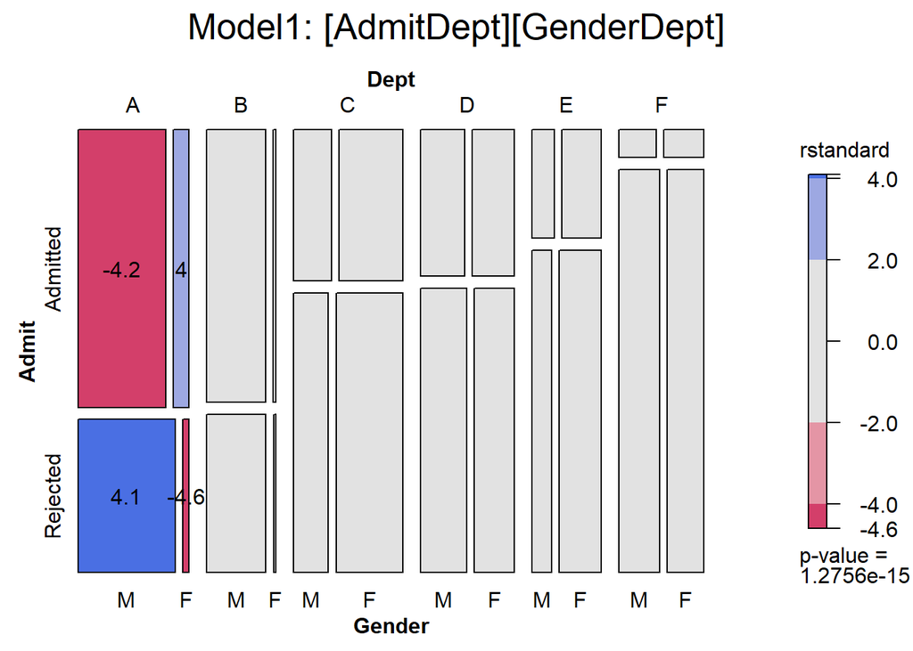

```r
mosaic(berk.glm1, shade = TRUE,
       formula = ~Dept + Admit + Gender, split = TRUE,
       residuals_type = "rstandard",
       main = "Model1: [AdmitDept][GenderDept]",
       labeling = labeling_residuals,
       abbreviate_labs = c(Gender = TRUE),
       keep_aspect_ratio = FALSE)
```

`residuals_type = "rstandard"`로 지정하게 되면, 표준화된 잔차를 출력할 수 있다.  
**Dept**를 공동 독립으로 가정한 후, **로그선형 모델**을 적합시켰을때의 결과를 모자이크 플랏을 통해 나타내었다.  
잔차의 색깔을 통해 **Dept = A, Gender = Male, Admit = Rejected**는 관찰빈도가 기대빈도보다 높기 때문에, 남성의 경우 A부서에 탈락을 많이 하는 경향이 있음을 알 수 있고 **Dept = A, Gender = Female, Admit = Admitted**는 관찰빈도가 기대빈도보다 높기 때문에, 여성의 경우 A부서에 합격을 많이 하는 경향이 있음을 알 수 있다.

```r
berkeley <- within(berkeley,
                   dept1AG <- (Dept == "A") *
                     (Gender == "Female") *
                     (Admit == "Admitted"))
head(berkeley)
```

```
##      Admit Gender Dept Freq dept1AG
## 1 Admitted   Male    A  512       0
## 2 Rejected   Male    A  313       0
## 3 Admitted Female    A   89       1
## 4 Rejected Female    A   19       0
## 5 Admitted   Male    B  353       0
## 6 Rejected   Male    B  207       0
```

**dept1AG**변수의 경우, **Dept = A, Gender = Female, Admit = Admitted**인 경우에 1을 갖고 나머지의 경우 0을 갖게한다.

```r
berk.glm3 <- glm(Freq ~ Dept * (Gender + Admit) + dept1AG,
                 data = berkeley, family = "poisson")
```

위의 모델은 **Dept, (Gender,Admit)**을 **dept1AG**에 대해 공동적인 독립을 가정한 모형을 적합시킨 모델이다.

```r
LRstats(berk.glm3)
```

```
## Likelihood summary table:
##              AIC    BIC LR Chisq Df Pr(>Chisq)
## berk.glm3 199.74 222.12   2.6815  5     0.7489
```

유의확률이 유의수준 0.05보다 높으므로 귀무가설을 기각하지 못한다. 따라서, **berk.glm3**모형은 유의한 모형임을 확인할 수 있다.

```r
anova(berk.glm1, berk.glm3, test = "Chisq")
```

```
## Analysis of Deviance Table
##
## Model 1: Freq ~ Dept * (Gender + Admit)
## Model 2: Freq ~ Dept * (Gender + Admit) + dept1AG
##   Resid. Df Resid. Dev Df Deviance  Pr(>Chi)
## 1         6    21.7355
## 2         5     2.6815  1   19.054 1.271e-05 ***
## ---
## Signif. codes:  0 '***' 0.001 '**' 0.01 '*' 0.05 '.' 0.1 ' ' 1
```

또한, `anova`를 통해 **berk.glm1**과 **berk.glm3**를 비교해본 결과, 유의확률이 유의수준 0.05보다 작은것을 확인할 수 있다.  
따라서, 유의한 잔차의 차이가 있으므로 **berk.glm3**는 유의한 모델이라는 것을 한 번 더 확인할 수 있다.

```r
coef(berk.glm3)[["dept1AG"]]
```

```
## [1] 1.052076
```

```r
exp(coef(berk.glm3)[["dept1AG"]])
```

```
## [1] 2.86359
```

**berk.glm3**의 **dept1AG**계수를 이용해 오즈비를 구한 결과, **exp(1.05) = 2.86**이라는 값을 얻을 수 있었다.  
이는 **dept1AG**변수가 한 단위 증가할때, 그렇지 않을 사람보다 빈도가 높아질 오즈가 약 2.86배 증가한다는 것을 확인할 수 있다.

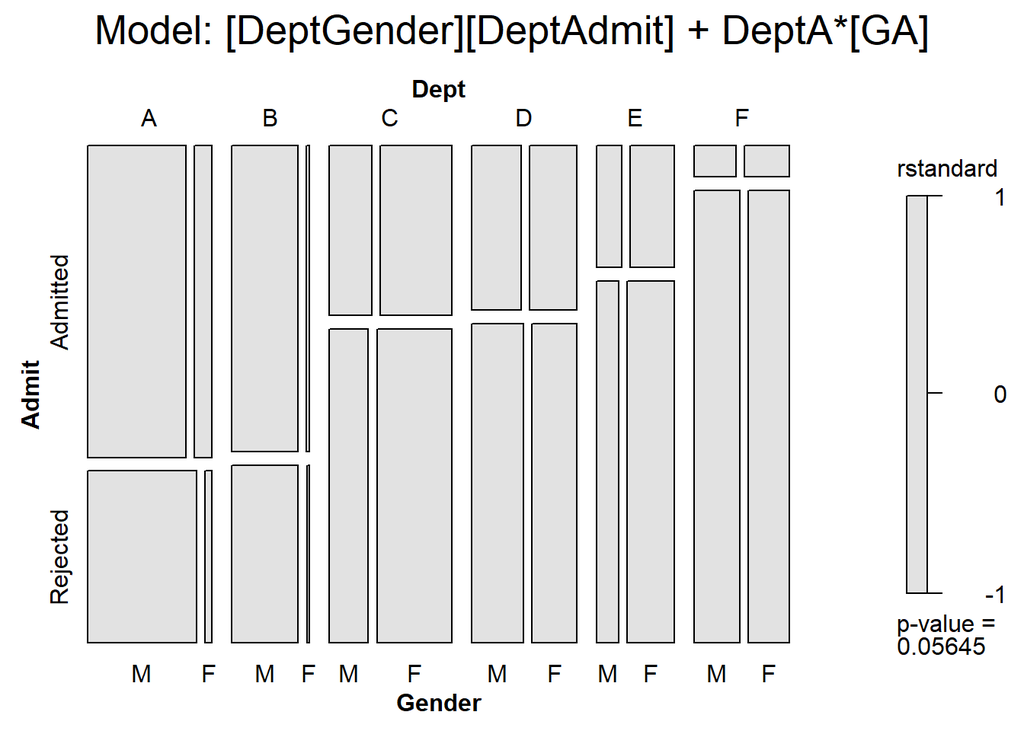

```r
mosaic(berk.glm3, shade = TRUE,
       formula = ~ Dept + Admit + Gender, split = TRUE,
       residuals_type = "rstandard",
       main = "Model: [DeptGender][DeptAdmit] + DeptA*[GA]",
       labeling = labeling_residuals,
       abbreviate_labs = c(Gender = TRUE),
       keep_aspect_ratio = FALSE)
```

**berk.glm3** 모델의 결과를 모자이크 플롯을 통해 나타낸 결과, 유의확률이 유의수준 0.05보다 크므로 모든 변수들은 서로 독립인 것을 알 수 있다.  
또한, 특정 잔차의 패턴이 보이지 않는 것을 확인할 수 있다.  
하지만, P-value가 0.05에 가까우므로 **Partial association**분석을 통해 부분관계를 살펴봄으로써 연관된 변수를 찾을수도 있다.

## 9.4 Equivalent logit models

로그선형 모형은 설명변수와 반응변수를 구분하지 않지만, **logit모형**은 설명변수를 통해 한 반응변수에 대한 로그 확률이 어떻게 변하는지를 보여준다.

*Example 9.3: Berkeley admissions*

```r
(obs <- log(UCBAdmissions[1,,] / UCBAdmissions[2,,]))
```

```
##         Dept
## Gender            A          B          C          D          E          F
##   Male    0.4921214  0.5337493 -0.5355182 -0.7039581 -0.9569618 -2.7697438
##   Female  1.5441974  0.7537718 -0.6604399 -0.6219709 -1.1571488 -2.5808479
```

log(`Admit = Admitted` / `Admit = Rejectd`)를 통해 로그 합격 확률을 구할 수 있다.

```r
berk.logit2 <- glm(Admit == "Admitted" ~ Dept + Gender,
                   data = berkeley,
                   weights = Freq,
                   family = "binomial")
summary(berk.logit2)
```

```
##
## Call:
## glm(formula = Admit == "Admitted" ~ Dept + Gender, family = "binomial",
##     data = berkeley, weights = Freq)
##
## Deviance Residuals:
##      Min        1Q    Median        3Q       Max
## -25.3424  -13.0584   -0.1631   16.0167   21.3199
##
## Coefficients:
##              Estimate Std. Error z value Pr(>|z|)
## (Intercept)   0.58205    0.06899   8.436   <2e-16 ***
## DeptB        -0.04340    0.10984  -0.395    0.693
## DeptC        -1.26260    0.10663 -11.841   <2e-16 ***
## DeptD        -1.29461    0.10582 -12.234   <2e-16 ***
## DeptE        -1.73931    0.12611 -13.792   <2e-16 ***
## DeptF        -3.30648    0.16998 -19.452   <2e-16 ***
## GenderFemale  0.09987    0.08085   1.235    0.217
## ---
## Signif. codes:  0 '***' 0.001 '**' 0.01 '*' 0.05 '.' 0.1 ' ' 1
##
## (Dispersion parameter for binomial family taken to be 1)
##
##     Null deviance: 6044.3  on 23  degrees of freedom
## Residual deviance: 5187.5  on 17  degrees of freedom
## AIC: 5201.5
##
## Number of Fisher Scoring iterations: 6
```

**Admit == Admitted**를 반응변수로 하고 설명변수는 **Dept, Gender**로 하는 로짓 모형을 적합시켰다.  
**Dept = B**, **Gender**변수는 유의확률이 유의수준 크므로 유의하지 않은 변수임을 알 수 있다.  
**Dept = B**, **Gender**변수를 제외한 나머지 변수들의 유의확률은 유의수준 0.05보다 작으므로 유의한 변수임을 확인할 수 있다.

```r
berkeley <- within(berkeley,
                   dept1AG <- (Dept == "A") * (Gender == "Female"))
berk.logit3 <- glm(Admit == "Admitted" ~ Dept + Gender + dept1AG, data = berkeley, weights = Freq, family = "binomial")
summary(berk.logit3)
```

```
##
## Call:
## glm(formula = Admit == "Admitted" ~ Dept + Gender + dept1AG,
##     family = "binomial", data = berkeley, weights = Freq)
##
## Deviance Residuals:
##      Min        1Q    Median        3Q       Max
## -24.6314  -13.1867    0.0142   15.8566   22.1022
##
## Coefficients:
##              Estimate Std. Error z value Pr(>|z|)
## (Intercept)   0.49212    0.07175   6.859 6.94e-12 ***
## DeptB         0.05206    0.11187   0.465    0.642
## DeptC        -1.08802    0.11425  -9.523  < 2e-16 ***
## DeptD        -1.14250    0.11157 -10.240  < 2e-16 ***
## DeptE        -1.56102    0.13272 -11.762  < 2e-16 ***
## DeptF        -3.15321    0.17336 -18.189  < 2e-16 ***
## GenderFemale -0.03069    0.08676  -0.354    0.724
## dept1AG       1.08277    0.27666   3.914 9.09e-05 ***
## ---
## Signif. codes:  0 '***' 0.001 '**' 0.01 '*' 0.05 '.' 0.1 ' ' 1
##
## (Dispersion parameter for binomial family taken to be 1)
##
##     Null deviance: 6044.3  on 23  degrees of freedom
## Residual deviance: 5169.8  on 16  degrees of freedom
## AIC: 5185.8
##
## Number of Fisher Scoring iterations: 6
```

**Dept = A, Gender = Female**을 만족하는 변수를 **dept1AG**로 설정하여 다시 한 번 모형을 적합시켜 보았다.  
앞선 결과와 같이 **Dept = B**, **Gender**는 유의하지 않지만, **dept1AG**는 반응변수에 유의한 영향을 미치는 것읋 확인할 수 있다.

```r
library(car)
Anova(berk.logit2)
```

```
## Analysis of Deviance Table (Type II tests)
##
## Response: Admit == "Admitted"
##        LR Chisq Df Pr(>Chisq)
## Dept     763.40  5     <2e-16 ***
## Gender     1.53  1     0.2159
## ---
## Signif. codes:  0 '***' 0.001 '**' 0.01 '*' 0.05 '.' 0.1 ' ' 1
```

```r
Anova(berk.logit3)
```

```
## Analysis of Deviance Table (Type II tests)
##
## Response: Admit == "Admitted"
##         LR Chisq Df Pr(>Chisq)
## Dept      646.72  5  < 2.2e-16 ***
## Gender      0.13  1     0.7236
## dept1AG    17.65  1  2.658e-05 ***
## ---
## Signif. codes:  0 '***' 0.001 '**' 0.01 '*' 0.05 '.' 0.1 ' ' 1
```

`Anova`함수를 통해서도 각 변수들의 수준을 모두 고려했을 때 유의한지 유의하지 않은지를 확인할 수 있다.  
**Gender**변수는 유의하지 않은 것을 알 수 있고 **Dept**변수의 경우, **Dept = B**는 유의하지 않지만 나머지 **Dept**의 수준들이 유의하기 때문에 유의한 변수로 나오는 것을 확인할 수 있다.

```r
pred2 <- cbind(berkeley[,1:3], fit = predict(berk.logit2))
pred2 <- cbind(subset(pred2, Admit == "Admitted"), obs = as.vector(obs))
head(pred2)
```

```
##       Admit Gender Dept        fit        obs
## 1  Admitted   Male    A  0.5820514  0.4921214
## 3  Admitted Female    A  0.6819215  1.5441974
## 5  Admitted   Male    B  0.5386535  0.5337493
## 7  Admitted Female    B  0.6385236  0.7537718
## 9  Admitted   Male    C -0.6805466 -0.5355182
## 11 Admitted Female    C -0.5806765 -0.6604399
```

**berk.logit2**모형을 통해 각 변수의 수준이 주어질때의 합격에 대한 예측확률과 앞서 구해봤던 로그 합격률을 **pred2**데이터에 적합시켰다.

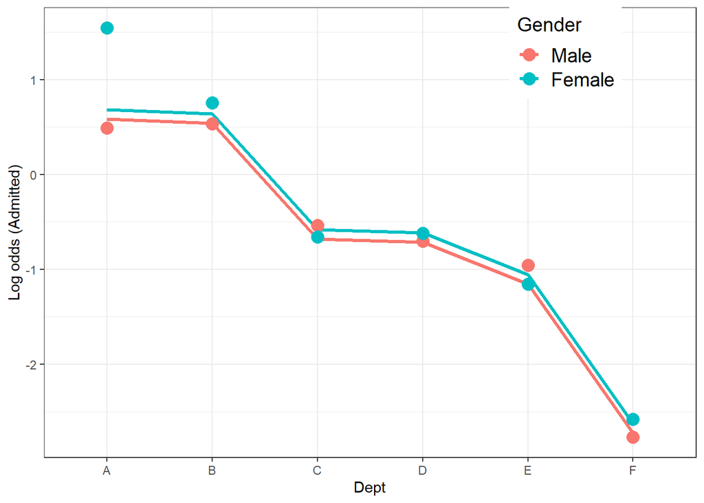

```r
library(ggplot2)
ggplot(pred2, aes(x = Dept, y = fit, group = Gender, color = Gender)) +
  geom_line(size = 1.2) +
  geom_point(aes(x = Dept, y = obs, group = Gender, color = Gender), size = 4) +
  ylab("Log odds (Admitted)") + theme_bw() +
  theme(legend.position = c(.8, .9),
        legend.title = element_text(size = 14),
        legend.text = element_text(size = 14))
```

```r
pred3 <- cbind(berkeley[,1:3], fit = predict(berk.logit3))
pred3 <- cbind(subset(pred3, Admit == "Admitted"), obs = as.vector(obs))
head(pred2)
```

```
##       Admit Gender Dept        fit        obs
## 1  Admitted   Male    A  0.5820514  0.4921214
## 3  Admitted Female    A  0.6819215  1.5441974
## 5  Admitted   Male    B  0.5386535  0.5337493
## 7  Admitted Female    B  0.6385236  0.7537718
## 9  Admitted   Male    C -0.6805466 -0.5355182
## 11 Admitted Female    C -0.5806765 -0.6604399
```

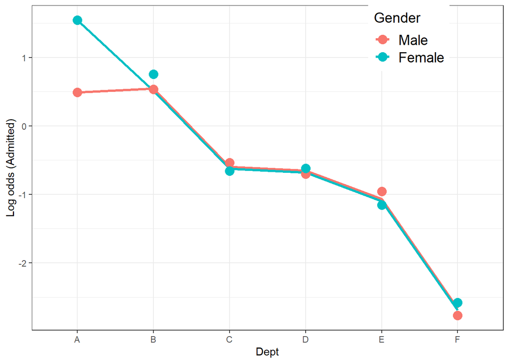

```r
library(ggplot2)
ggplot(pred3, aes(x = Dept, y = fit, group = Gender, color = Gender)) +
  geom_line(size = 1.2) +
  geom_point(aes(x = Dept, y = obs, group = Gender, color = Gender), size = 4) +
  ylab("Log odds (Admitted)") + theme_bw() +
  theme(legend.position = c(.8, .9),
        legend.title = element_text(size = 14),
        legend.text = element_text(size = 14))
```

## 9.5 Zero frequencies

데이터에서 발생빈도가 0인경우, 로그선형 및 로짓모형을 적합시킴에 있어 문제를 발생시킬 수 있다.  
이러한 경우, 전처리를 통해 발생빈도가 없는 데이터를 제거하거나 데이터를 더 수집하여 발생빈도가 0이 나오지 않도록 하는 방법을 활용할 수 있다.

*Example 9.4: Heath concerns of teenagers*

```r
Health <- expand.grid(concerns = c("sex", "menstrual",
                                   "healthy", "nothing"),
                      age = c("12-15","16-17"),
                      gender = c("M","F"))
Health$Freq <- c(4,0,42,57,2,0,7,20,
                 9,4,19,71,7,8,10,21)
```

```r
health.glm0 <- glm(Freq ~ concerns + age + gender, data = Health, subset = (Freq > 0), family = poisson)
health.glm1 <- glm(Freq ~ concerns + age * gender, data = Health, subset = (Freq > 0), family = poisson)
```

`health`데이터의 경우, 발생빈도가 0인 데이터가 있는 것을 확인할 수 있다. 따라서, `subset`옵션을 활용하여 발생빈도가 0인 경우는 제외하고 모델을 적합시킨다.  
**health.glm0**의 경우 주효과들로만 모델을 적합시키고 **health.glm1**의 경우 주효과와 더불어 **age**와 **gender**의 교호작용 항도 포함시킨다.

```r
LRstats(health.glm0, health.glm1)
```

```
## Likelihood summary table:
##                 AIC    BIC LR Chisq Df Pr(>Chisq)
## health.glm0 100.742 104.58   27.744  8  0.0005256 ***
## health.glm1  99.884 104.36   24.886  7  0.0007951 ***
## ---
## Signif. codes:  0 '***' 0.001 '**' 0.01 '*' 0.05 '.' 0.1 ' ' 1
```

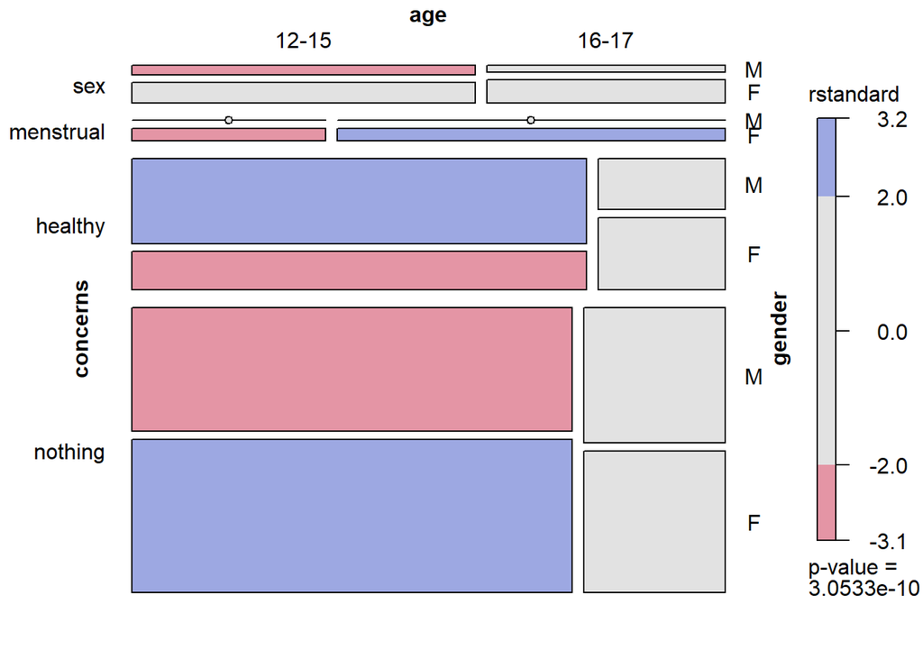

```r
mosaic(health.glm1, ~ concerns + age + gender,
       residuals_type = "rstandard",
       rot_labels = 0,
       just_labels = c(left = "right"),
       margin = c(left = 5))
```

**health.glm1**의 결과를 모자이크 플롯을 통해 나타내 보았다.  
여성의 경우, 12-15세에는 월경에대한 걱정이 낮지만, 16-17세의 경우 월경에대한 걱정이 많아지는 것을 확인할 수 있다.  
또한, 12-15세의 남성의 경우 건강에대한 걱정이 많지만, 여성의 경우에는 낮은 것읋 확인할 수 있다.

```r
health.glm2 <- glm(Freq ~ concerns*gender + concerns*age,
                   data = Health, subset = (Freq > 0),
                   family = poisson)
LRstats(health.glm2)
```

```
## Likelihood summary table:
##               AIC   BIC LR Chisq Df Pr(>Chisq)
## health.glm2 87.66 94.69   4.6611  3     0.1984
```

`concerns`을 공동 독립 변수로 가정한 후, `glm`의 `family = poisson`을 통해 공동 독립 모형을 가정해 보았다.  
유의확률이 유의수준 0.05보다 높으므로 귀무가설을 기각하지 못한다.  
따라서, **health.glm2**모델은 유의한 모델임을 확인할 수 있다.

```r
summary(health.glm2)
```

```
##
## Call:
## glm(formula = Freq ~ concerns * gender + concerns * age, family = poisson,
##     data = Health, subset = (Freq > 0))
##
## Deviance Residuals:
##       1        3        4        5        7        8        9       10
##  0.2365   0.5852  -0.1734  -0.2999  -1.2022   0.3018  -0.1490   0.0000
##      11       12       13       14       15       16
## -0.7951   0.1576   0.1757   0.0000   1.3479  -0.2821
##
## Coefficients: (1 not defined because of singularities)
##                            Estimate Std. Error z value Pr(>|z|)
## (Intercept)                  1.2657     0.4451   2.843  0.00446 **
## concernsmenstrual           -0.8602     0.5865  -1.467  0.14246
## concernshealthy              2.3803     0.4713   5.051  4.4e-07 ***
## concernsnothing              2.8003     0.4615   6.067  1.3e-09 ***
## genderF                      0.9808     0.4787   2.049  0.04047 *
## age16-17                    -0.3677     0.4336  -0.848  0.39643
## concernsmenstrual:genderF        NA         NA      NA       NA
## concernshealthy:genderF     -1.5054     0.5330  -2.824  0.00474 **
## concernsnothing:genderF     -0.8028     0.5030  -1.596  0.11047
## concernsmenstrual:age16-17   1.0609     0.7504   1.414  0.15741
## concernshealthy:age16-17    -0.9099     0.5131  -1.773  0.07615 .
## concernsnothing:age16-17    -0.7707     0.4693  -1.642  0.10052
## ---
## Signif. codes:  0 '***' 0.001 '**' 0.01 '*' 0.05 '.' 0.1 ' ' 1
##
## (Dispersion parameter for poisson family taken to be 1)
##
##     Null deviance: 252.4670  on 13  degrees of freedom
## Residual deviance:   4.6611  on  3  degrees of freedom
## AIC: 87.66
##
## Number of Fisher Scoring iterations: 4
```

**cocenrs = healthy, concerns = nothing, gender = F, concerns = healthy : gender = F**변수를 제외하고 대부분의 변수들이 유의하지 않은 변수임을 확인할 수 있다.

```r
health.tab <- xtabs(Freq ~ concerns + age + gender, data = Health)
```

```r
nonzeros <- ifelse(health.tab >0, 1, 0)
health.loglm0 <- loglm(~ concerns + age + gender,
                       data = health.tab, start = nonzeros)
health.loglm1 <- loglm(~ concerns + age * gender,
                       data = health.tab, start = nonzeros)
health.loglm2 <- loglm(~ concerns*gender + concerns*age,
                       data = health.tab, start = nonzeros)
LRstats(health.loglm0, health.loglm1, health.loglm2)
```

```
## Likelihood summary table:
##                  AIC    BIC LR Chisq Df Pr(>Chisq)
## health.loglm0 104.74 110.92  27.7435  8  0.0005256 ***
## health.loglm1 103.88 110.84  24.8856  7  0.0007951 ***
## health.loglm2  93.66 104.48   4.6611  2  0.0972446 .
## ---
## Signif. codes:  0 '***' 0.001 '**' 0.01 '*' 0.05 '.' 0.1 ' ' 1
```

발생빈도가 0인 변수의 경우 0으로, 발생빈도가 0보다 큰 경우 1로 코딩을 한 후, 교차표를 만들어 로그 선형 모델에 적합시켜 보았다.  
앞선 결과와 동일하게 **concerns**를 공동독립을 가정하는 경우에만 모형이 유의하고 나머지 두 개의 모형은 유의하지 않게 나오는 것을 확인할 수 있다.

**Summary of chapter9**